### Billboard Hot100 2014 in brief

Hossein Parsa

#### Introduction

The [Billboard Hot100](http://www.billboard.com/charts/hot-100) is a chart that ranks the best performing singles of the United States and is published weekly by Billboard Magazine. The ranking is based on radio play, online streaming and sales figures.

#### Data acquisition and processing

The data for the Billboard Hot100 2014 chart was scraped using `Python` code in two steps of downloading the source code from Billboard website ([GitHub](https://github.com/hparsa741/Data/blob/master/Hot100_2014_getSource.py)) and extracting the data from the source code ([GitHub](https://github.com/hparsa741/Data/blob/master/Hot100_2014_extact.py)). Once the data is available in csv format ([GitHub](https://github.com/hparsa741/Data/blob/master/Hot100_2014.csv)) we begin reading the file and analyzing the data using `R`.

```r
data <- data.frame(read.csv("Hot100_2014.csv"))
library(sqldf)
library(dplyr)
library(ggplot2)
```

#### Uniques

Number of Unique Artists

```r
length(unique(data$singer))
```

```
## [1] 259
```

Number of unique Songs

```r
dim(unique(data[c("singer", "song")]))[1]
```

```
## [1] 494
```

Average song per artist

```r
dim(unique(data[c("singer", "song")]))[1]/length(unique(data$singer))
```

```
## [1] 1.907336
```

#### Position 1

Artists and count of weeks holding Position 1

```r
pos1<-data[which(data$pos == 1),]
arrange(summarize(group_by(pos1, singer), weeks = n()), desc(weeks))
```

```
## Source: local data frame [9 x 2]
##
##              singer weeks
## 1 Pharrell Williams    10
## 2      Taylor Swift     9
## 3    Meghan Trainor     8
## 4       Iggy Azalea     7
## 5            MAGIC!     6
## 6        Katy Perry     4
## 7       John Legend     3
## 8           Pitbull     3
## 9            Eminem     2
```

Songs and count of weeks holding Position 1

```r
pos1song<-aggregate(pos1$pos, list(singer=pos1$singer, song=pos1$song), sum)
names(pos1song)<-c("singer", "song", "weeks")
arrange(pos1song, desc(weeks))
```

```
##               singer                song weeks
## 1  Pharrell Williams               Happy    10
## 2     Meghan Trainor All About That Bass     8
## 3        Iggy Azalea               Fancy     7
## 4             MAGIC!                Rude     6
## 5       Taylor Swift         Blank Space     5
## 6         Katy Perry          Dark Horse     4
## 7       Taylor Swift        Shake It Off     4
## 8        John Legend           All Of Me     3
## 9            Pitbull              Timber     3
## 10            Eminem         The Monster     2
```

#### Songs weeks on chart distribution

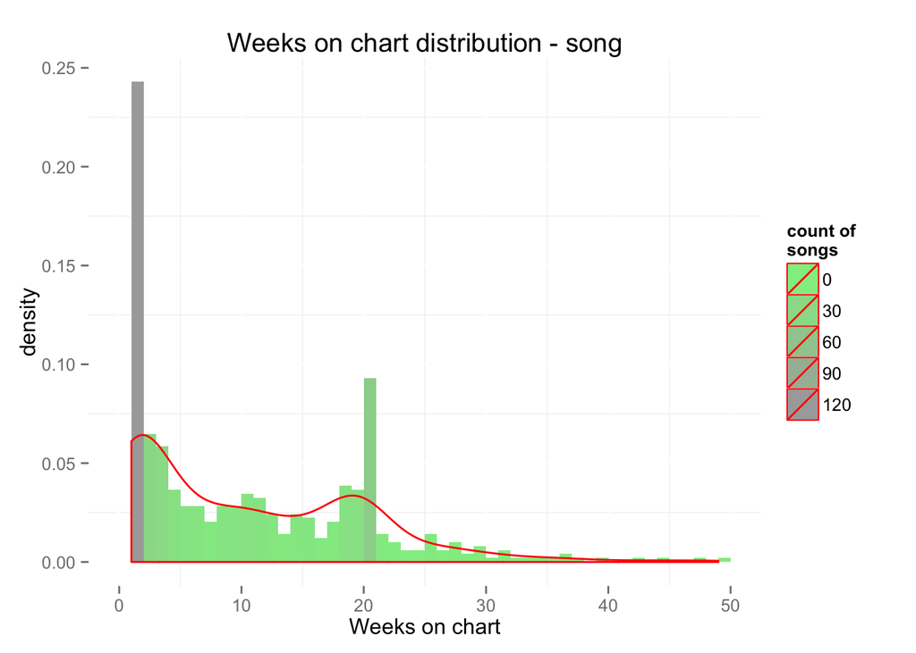

```r
sscount<-summarize(group_by(data, singer, song), count = n())
ggplot(sscount, aes(count))+geom_histogram(aes(y = ..density.., fill= ..count..), binwidth=1)+geom_density(color='red')+scale_fill_gradient("Count", low = "lightgreen", high = "darkgrey")+labs(title = "Weeks on chart distribution - song")+xlab("Weeks on chart")+guides(fill = guide_legend(title = "count of \nsongs", title.position = "top"))+theme(panel.background = element_rect(fill = "white"))
```

#### Artists with 5 or more unique song

```r
sqldf("with t as (select distinct singer, song from data) select singer, count(0) as countOfSong from t group by singer having count(0) > 4 order by 2 desc")
```

```
##                  singer countOfSong
## 1         One Direction          10
## 2          Taylor Swift           8
## 3   5 Seconds Of Summer           7
## 4  Florida Georgia Line           7
## 5          Jason Aldean           7
## 6               Beyonce           6
## 7            Ed Sheeran           6
## 8                Eminem           6
## 9            Katy Perry           6
## 10                Lorde           6
## 11           Luke Bryan           6
## 12        Ariana Grande           5
## 13        Calvin Harris           5
## 14          Chris Brown           5
## 15                Drake           5
## 16              Pitbull           5
```

#### Songs per artist distribution

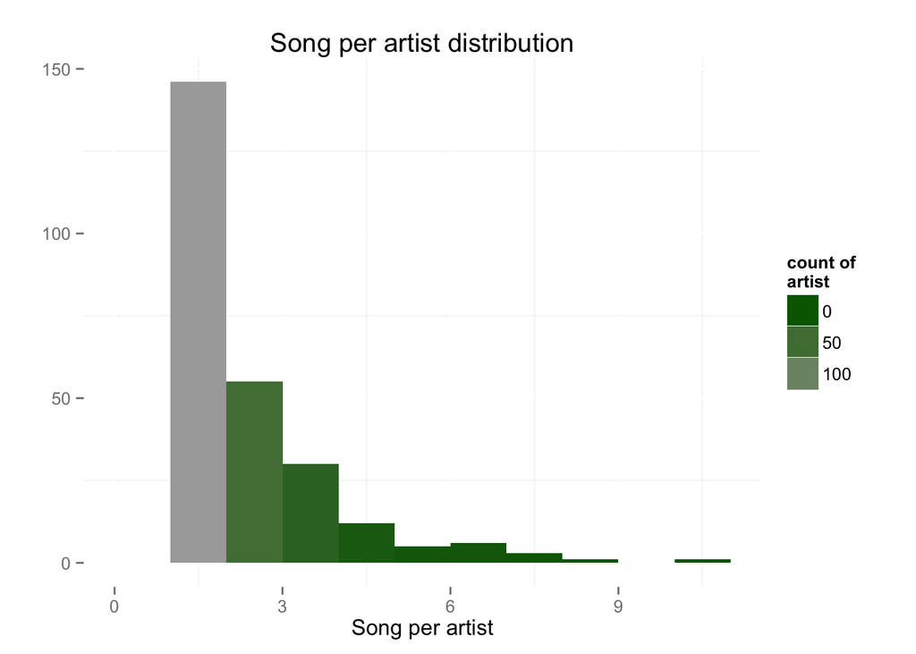

```r
ggplot(sqldf("with t as (select distinct singer, song from data) select singer, count(0) as countOfSong from t group by singer order by 2 desc"), aes(countOfSong))+geom_histogram(aes( fill= ..count..), binwidth=1)+scale_fill_gradient("Count", low = "darkgreen", high = "darkgrey")+labs(title = "Song per artist distribution")+xlab("Song per artist")+ylab("")+guides(fill = guide_legend(title = "count of \nartist", title.position = "top"))+theme(panel.background = element_rect(fill = "white"))
```

#### Top weeks on chart artists

45 or more weeks on chart

```r
sqldf("select singer, count(0) as Weeks_on_Chart from (select distinct singer, weekNo from data) group by singer having count(0) >= 45 order by 2 desc, 1")
```

```
##                  singer Weeks_on_Chart
## 1           Chris Brown             52
## 2  Florida Georgia Line             52
## 3          Jason Derulo             52
## 4            Luke Bryan             52
## 5            Katy Perry             50
## 6               Kid Ink             50
## 7           John Legend             49
## 8         Blake Shelton             48
## 9     Pharrell Williams             47
## 10              Pitbull             47
## 11           Trey Songz             47
## 12     Brantley Gilbert             45
## 13        Calvin Harris             45
## 14          OneRepublic             45
```

Weeks on chart distribution

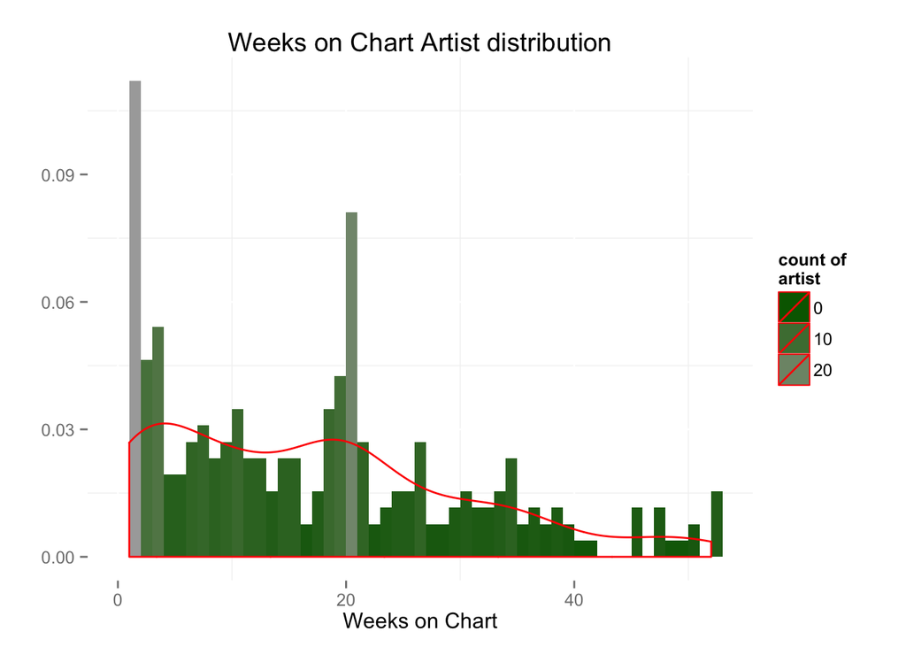

```r
ggplot(sqldf("select singer, count(0) as Weeks_on_Chart from (select distinct singer, weekNo from data) group by singer order by 2 desc, 1"), aes(Weeks_on_Chart))+geom_histogram(aes(y=..density.., fill= ..count..), binwidth=1)+geom_density(color='red')+scale_fill_gradient("Count", low = "darkgreen", high = "darkgrey")+labs(title = "Weeks on Chart Artist distribution")+xlab("Weeks on Chart")+ylab("")+guides(fill = guide_legend(title = "count of \nartist", title.position = "top"))+theme(panel.background = element_rect(fill = "white"))
```

Top 15 Artists appeared most on chart

```r
singerOnChart<-aggregate( pos ~ singer, data = data, FUN = length)
names(singerOnChart)<-c("Artist", "Weeks")
head(singerOnChart[with(singerOnChart, order(-Weeks)),], 15)
```

```
##                   Artist Weeks
## 125           Katy Perry   108
## 95           Iggy Azalea    91
## 103         Jason Derulo    88
## 186              Pitbull    72
## 96       Imagine Dragons    71
## 82  Florida Georgia Line    69
## 20               Beyonce    66
## 143                Lorde    65
## 178          OneRepublic    65
## 42           Chris Brown    64
## 66                 Drake    64
## 10         Ariana Grande    62
## 69            Ed Sheeran    61
## 184    Pharrell Williams    60
## 145           Luke Bryan    59
```

#### Top weeks on chart songs

30 or more weeks on chart

```r
sqldf("select singer, song, count(0) as Weeks_on_Chart from (select distinct singer, song, weekNo from data) group by singer, song having count(0) >= 30 order by 3 desc, 1")
```

```
##               singer                song Weeks_on_Chart
## 1        John Legend           All Of Me             49
## 2  Pharrell Williams               Happy             47
## 3         Katy Perry          Dark Horse             44
## 4        OneRepublic      Counting Stars             42
## 5        Iggy Azalea               Fancy             39
## 6           DJ Snake  Turn Down For What             37
## 7        Chris Brown               Loyal             36
## 8          Sam Smith        Stay With Me             36
## 9           Bastille             Pompeii             35
## 10            MAGIC!                Rude             34
## 11      Jason Derulo          Talk Dirty             33
## 12               Sia          Chandelier             32
## 13  American Authors Best Day Of My Life             31
## 14        Disclosure               Latch             31
## 15              Nico          Am I Wrong             31
## 16      Idina Menzel           Let It Go             30
```

Weeks on chart distribution

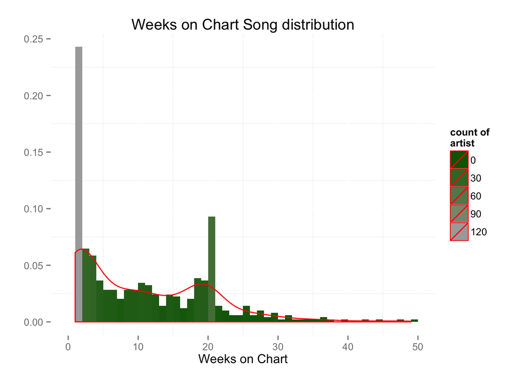

```r
ggplot(sqldf("select singer, song, count(0) as Weeks_on_Chart from (select distinct singer, song, weekNo from data) group by singer, song order by 3 desc, 1"), aes(Weeks_on_Chart))+geom_histogram(aes(y=..density.., fill= ..count..), binwidth=1)+geom_density(color='red')+scale_fill_gradient("Count", low = "darkgreen", high = "darkgrey")+labs(title = "Weeks on Chart Song distribution")+xlab("Weeks on Chart")+ylab("")+guides(fill = guide_legend(title = "count of \nartist", title.position = "top"))+theme(panel.background = element_rect(fill = "white"))
```

Positions of top 10 longest on chart songs

```r
topSong<-aggregate(data$pos, list(singer=data$singer, song=data$song), length)
head(topSong[order(-topSong[,3]),],10)
```

```
##                singer               song  x
## 23        John Legend          All Of Me 49
## 169 Pharrell Williams              Happy 47
## 105        Katy Perry         Dark Horse 44
## 101       OneRepublic     Counting Stars 42
## 136       Iggy Azalea              Fancy 39
## 435          DJ Snake Turn Down For What 37
## 254       Chris Brown              Loyal 36
## 371         Sam Smith       Stay With Me 36
## 309          Bastille            Pompeii 35
## 331            MAGIC!               Rude 34
```

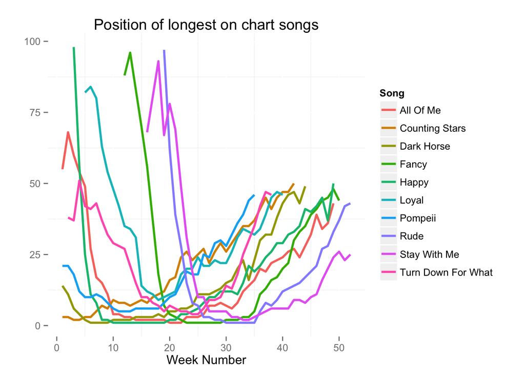

```r
topSong<-head(topSong[order(-topSong[,3]),],10)
topAll <- data[data$song %in% head(topSong[order(-topSong[,3]),],10)$song & data$singer %in% head(topSong[order(-topSong[,3]),],10)$singer,]

ggplot(topAll, aes(weekNo, pos))+geom_line(aes(col=topAll$song),size=1)+labs(title = "Position of longest on chart songs", colour="Song")+xlab("Week Number")+ylab("")+guides(fill = guide_legend(title = "count of \nartist", title.position = "top"))+theme(panel.background = element_rect(fill = "white"))
```